# Glue and S3 parameters

| year pct short | fe_c_i 2001 0.01 | fe_c_i 2001 0.05 | fe_c_i 2001 0.1 | fe_c_i 2001 0.25 | fe_c_i 2001 0.5 | fe_c_i 2001 0.75 | fe_c_i 2001 0.95 | fe_c_i 2001 0.99 | fe_c_i 2002 0.01 | fe_c_i 2002 0.05 | fe_c_i 2002 0.1 | fe_c_i 2002 0.25 | fe_c_i 2002 0.5 | fe_c_i 2002 0.75 | fe_c_i 2002 0.95 | fe_c_i 2002 0.99 | fe_c_i 2003 0.01 | fe_c_i 2003 0.05 | fe_c_i 2003 0.1 | fe_c_i 2003 0.25 | fe_c_i 2003 0.5 | fe_c_i 2003 0.75 | fe_c_i 2003 0.95 | fe_c_i 2003 0.99 | fe_c_i 2004 0.01 | fe_c_i 2004 0.05 | fe_c_i 2004 0.1 | fe_c_i 2004 0.25 | fe_c_i 2004 0.5 | … |
| --- | --- | --- | --- | --- | --- | --- | --- | --- | --- | --- | --- | --- | --- | --- | --- | --- | --- | --- | --- | --- | --- | --- | --- | --- | --- | --- | --- | --- | --- | --- |
| Education and Sport Activity" | 78.00 | 439.00 | 3,995.00 | 4,005.00 | 6,557.00 | 14,079.00 | 15,751.00 | 15,751.00 | 78.00 | 434.00 | 3,995.00 | 4,005.00 | 8,642.00 | 14,079.00 | 15,751.00 | 15,751.00 | 431.00 | 3,995.00 | 4,003.00 | 6,917.00 | 14,079.00 | 14,790.00 | 15,751.00 | 15,751.00 | 81.00 | 3,995.00 | 3,996.00 | 6,917.00 | 8,483.00 | … |
| Fur | 408.00 | 3,968.00 | 3,968.00 | 6,737.00 | 8,467.00 | 12,506.00 | 15,119.00 | 16,774.00 | 408.00 | 3,968.00 | 5,110.00 | 6,737.00 | 6,737.00 | 10,538.00 | 15,119.00 | 15,735.00 | 732.00 | 3,968.00 | 5,108.00 | 6,737.00 | 8,928.00 | 10,096.00 | 15,433.00 | 16,775.00 | 732.00 | 3,969.00 | 5,109.00 | 6,737.00 | 8,467.00 | … |
| Manufacture of Wood | 413.00 | 415.00 | 1,999.00 | 5,113.00 | 7,030.00 | 9,682.00 | 14,916.00 | 15,989.00 | 414.00 | 1,356.00 | 2,618.00 | 5,671.00 | 7,760.00 | 11,631.00 | 15,353.00 | 16,781.00 | 736.00 | 3,413.00 | 3,805.00 | 6,545.00 | 8,823.00 | 11,251.00 | 15,353.00 | 17,793.00 | 413.00 | 3,413.00 | 3,975.00 | 6,205.00 | 8,823.00 | … |
| Beverages | 34.00 | 38.00 | 828.00 | 3,854.00 | 10,063.00 | 15,233.00 | 17,080.00 | 17,785.00 | 34.00 | 36.00 | 376.00 | 3,831.00 | 10,703.00 | 15,102.00 | 17,711.00 | 18,471.00 | 377.00 | 988.00 | 1,843.00 | 3,478.00 | 9,239.00 | 11,971.00 | 17,081.00 | 17,497.00 | 41.00 | 719.00 | 1,843.00 | 6,194.00 | 10,516.00 | … |
| Medicines | 112.00 | 113.00 | 481.00 | 2,985.00 | 6,358.00 | 13,120.00 | 17,813.00 | 18,324.00 | 112.00 | 113.00 | 481.00 | 3,340.00 | 7,164.00 | 14,110.00 | 18,016.00 | 18,324.00 | 480.00 | 772.00 | 1,964.00 | 4,050.00 | 8,250.00 | 14,112.00 | 18,016.00 | 18,337.00 | 112.00 | 116.00 | 771.00 | 4,049.00 | 7,310.00 | … |
| Non-metallic Products | 134.00 | 513.00 | 1,199.00 | 4,443.00 | 10,176.00 | 14,133.00 | 17,663.00 | 18,380.00 | 134.00 | 153.00 | 900.00 | 4,094.00 | 8,985.00 | 13,684.00 | 17,826.00 | 18,448.00 | 516.00 | 1,028.00 | 2,576.00 | 5,614.00 | 9,265.00 | 13,176.00 | 17,598.00 | 18,382.00 | 134.00 | 518.00 | 1,579.00 | 4,456.00 | 8,985.00 | … |
| Paper | 70.00 | 423.00 | 1,086.00 | 5,585.00 | 10,415.00 | 12,955.00 | 17,393.00 | 18,298.00 | 421.00 | 739.00 | 1,002.00 | 6,312.00 | 10,103.00 | 12,984.00 | 17,426.00 | 18,269.00 | 421.00 | 834.00 | 2,973.00 | 6,312.00 | 9,103.00 | 12,984.00 | 17,020.00 | 17,997.00 | 71.00 | 1,002.00 | 3,271.00 | 6,312.00 | 8,940.00 | … |
| Processing foods | 3.00 | 338.00 | 2,076.00 | 5,474.00 | 10,034.00 | 12,395.00 | 16,729.00 | 17,970.00 | 12.00 | 346.00 | 1,055.00 | 4,575.00 | 10,039.00 | 11,220.00 | 17,780.00 | 18,163.00 | 875.00 | 2,071.00 | 2,759.00 | 7,480.00 | 11,145.00 | 14,379.00 | 17,381.00 | 18,111.00 | 10.00 | 1,053.00 | 2,077.00 | 7,480.00 | 10,845.00 | … |
| Smelting Non-ferrous Metals | 166.00 | 541.00 | 910.00 | 4,114.00 | 6,801.00 | 14,162.00 | 17,887.00 | 18,419.00 | 538.00 | 542.00 | 1,536.00 | 4,121.00 | 12,330.00 | 13,851.00 | 17,887.00 | 18,342.00 | 803.00 | 1,138.00 | 1,787.00 | 4,119.00 | 10,612.00 | 15,504.00 | 17,887.00 | 18,434.00 | 164.00 | 1,785.00 | 2,213.00 | 4,697.00 | 7,336.00 | … |
| Tobacco | 44.00 | 2,105.00 | 3,804.00 | 8,617.00 | 12,439.00 | 16,061.00 | 18,220.00 | 18,640.00 | 44.00 | 2,105.00 | 3,857.00 | 8,617.00 | 12,439.00 | 16,759.00 | 18,262.00 | 18,640.00 | 381.00 | 2,105.00 | 3,857.00 | 8,327.00 | 12,346.00 | 17,712.00 | 18,317.00 | 18,640.00 | 44.00 | 1,178.00 | 3,176.00 | 7,968.00 | 12,261.00 | … |

```
Distribution of fe_t_i, by year and short
```

| year pct short | fe_t_i 2001 0.01 | fe_t_i 2001 0.05 | fe_t_i 2001 0.1 | fe_t_i 2001 0.25 | fe_t_i 2001 0.5 | fe_t_i 2001 0.75 | fe_t_i 2001 0.95 | fe_t_i 2001 0.99 | fe_t_i 2002 0.01 | fe_t_i 2002 0.05 | fe_t_i 2002 0.1 | fe_t_i 2002 0.25 | fe_t_i 2002 0.5 | fe_t_i 2002 0.75 | fe_t_i 2002 0.95 | fe_t_i 2002 0.99 | fe_t_i 2003 0.01 | fe_t_i 2003 0.05 | fe_t_i 2003 0.1 | fe_t_i 2003 0.25 | fe_t_i 2003 0.5 | fe_t_i 2003 0.75 | fe_t_i 2003 0.95 | fe_t_i 2003 0.99 | fe_t_i 2004 0.01 | fe_t_i 2004 0.05 | fe_t_i 2004 0.1 | fe_t_i 2004 0.25 | fe_t_i 2004 0.5 | … |
| --- | --- | --- | --- | --- | --- | --- | --- | --- | --- | --- | --- | --- | --- | --- | --- | --- | --- | --- | --- | --- | --- | --- | --- | --- | --- | --- | --- | --- | --- | --- |
| Computers and Other Electronic Equipment" | 364.00 | 365.00 | 367.00 | 369.00 | 372.00 | 380.00 | 384.00 | 387.00 | 754.00 | 755.00 | 758.00 | 760.00 | 762.00 | 771.00 | 776.00 | 779.00 | 1,150.00 | 1,152.00 | 1,155.00 | 1,159.00 | 1,161.00 | 1,161.00 | 1,165.00 | 1,165.00 | 1,573.00 | 1,576.00 | 1,583.00 | 1,586.00 | 1,588.00 | … |
| Artwork | 404.00 | 404.00 | 404.00 | 404.00 | 408.00 | 418.00 | 421.00 | 422.00 | 796.00 | 796.00 | 796.00 | 798.00 | 804.00 | 809.00 | 810.00 | 811.00 | 1,180.00 | 1,180.00 | 1,181.00 | 1,185.00 | 1,188.00 | 1,188.00 | 1,190.00 | 1,191.00 | 1,614.00 | 1,615.00 | 1,615.00 | 1,619.00 | 1,622.00 | … |
| Cultural measurement instruments | 389.00 | 390.00 | 392.00 | 396.00 | 399.00 | 399.00 | 403.00 | 403.00 | 780.00 | 782.00 | 783.00 | 787.00 | 791.00 | 792.00 | 795.00 | 795.00 | 1,166.00 | 1,166.00 | 1,166.00 | 1,168.00 | 1,173.00 | 1,175.00 | 1,179.00 | 1,179.00 | 1,593.00 | 1,593.00 | 1,593.00 | 1,593.00 | 1,596.00 | … |
| Electrical Machine | 0.00 | 0.00 | 0.00 | 0.00 | 0.00 | 0.00 | 0.00 | 0.00 | 752.00 | 752.00 | 752.00 | 752.00 | 752.00 | 752.00 | 752.00 | 752.00 | 1,124.00 | 1,125.00 | 1,127.00 | 1,129.00 | 1,132.00 | 1,138.00 | 1,147.00 | 1,148.00 | 1,545.00 | 1,546.00 | 1,548.00 | 1,550.00 | 1,553.00 | … |
| Machinery | 277.00 | 277.00 | 277.00 | 281.00 | 287.00 | 301.00 | 306.00 | 308.00 | 668.00 | 668.00 | 668.00 | 669.00 | 674.00 | 687.00 | 696.00 | 698.00 | 1,053.00 | 1,053.00 | 1,053.00 | 1,055.00 | 1,064.00 | 1,073.00 | 1,080.00 | 1,081.00 | 1,451.00 | 1,451.00 | 1,452.00 | 1,462.00 | 1,468.00 | … |
| Metals | 253.00 | 253.00 | 253.00 | 260.00 | 266.00 | 269.00 | 276.00 | 276.00 | 644.00 | 644.00 | 646.00 | 652.00 | 657.00 | 665.00 | 667.00 | 667.00 | 1,032.00 | 1,032.00 | 1,032.00 | 1,037.00 | 1,046.00 | 1,050.00 | 1,052.00 | 1,052.00 | 1,428.00 | 1,428.00 | 1,428.00 | 1,429.00 | 1,439.00 | … |
| Smelting Non-ferrous Metals | 245.00 | 245.00 | 245.00 | 246.00 | 249.00 | 251.00 | 252.00 | 252.00 | 632.00 | 632.00 | 632.00 | 633.00 | 636.00 | 641.00 | 643.00 | 643.00 | 1,020.00 | 1,020.00 | 1,021.00 | 1,021.00 | 1,025.00 | 1,031.00 | 1,031.00 | 1,031.00 | 1,412.00 | 1,412.00 | 1,413.00 | 1,417.00 | 1,427.00 | … |
| Smelting ferrous Metals | 241.00 | 241.00 | 241.00 | 241.00 | 242.00 | 243.00 | 244.00 | 244.00 | 628.00 | 628.00 | 628.00 | 628.00 | 628.00 | 630.00 | 631.00 | 631.00 | 1,016.00 | 1,016.00 | 1,016.00 | 1,016.00 | 1,017.00 | 1,018.00 | 1,019.00 | 1,019.00 | 1,408.00 | 1,408.00 | 1,408.00 | 1,410.00 | 1,410.00 | … |
| Special Purpose Machinery | 309.00 | 309.00 | 309.00 | 315.00 | 323.00 | 329.00 | 339.00 | 340.00 | 699.00 | 699.00 | 699.00 | 701.00 | 711.00 | 715.00 | 727.00 | 730.00 | 1,082.00 | 1,082.00 | 1,082.00 | 1,085.00 | 1,090.00 | 1,096.00 | 1,105.00 | 1,108.00 | 1,482.00 | 1,482.00 | 1,482.00 | 1,489.00 | 1,493.00 | … |
| Transport Equipment | 345.00 | 349.00 | 353.00 | 353.00 | 355.00 | 356.00 | 361.00 | 362.00 | 733.00 | 738.00 | 740.00 | 741.00 | 742.00 | 743.00 | 750.00 | 751.00 | 1,110.00 | 1,113.00 | 1,115.00 | 1,115.00 | 1,116.00 | 1,118.00 | 1,119.00 | 1,122.00 | 1,526.00 | 1,529.00 | 1,532.00 | 1,532.00 | 1,532.00 | … |

```
Distribution of fe_c_t, by year and short
```

| year pct short | fe_c_t 2001 0.01 | fe_c_t 2001 0.05 | fe_c_t 2001 0.1 | fe_c_t 2001 0.25 | fe_c_t 2001 0.5 | fe_c_t 2001 0.75 | fe_c_t 2001 0.95 | fe_c_t 2001 0.99 | fe_c_t 2002 0.01 | fe_c_t 2002 0.05 | fe_c_t 2002 0.1 | fe_c_t 2002 0.25 | fe_c_t 2002 0.5 | fe_c_t 2002 0.75 | fe_c_t 2002 0.95 | fe_c_t 2002 0.99 | fe_c_t 2003 0.01 | fe_c_t 2003 0.05 | fe_c_t 2003 0.1 | fe_c_t 2003 0.25 | fe_c_t 2003 0.5 | fe_c_t 2003 0.75 | fe_c_t 2003 0.95 | fe_c_t 2003 0.99 | fe_c_t 2004 0.01 | fe_c_t 2004 0.05 | fe_c_t 2004 0.1 | fe_c_t 2004 0.25 | fe_c_t 2004 0.5 | … |
| --- | --- | --- | --- | --- | --- | --- | --- | --- | --- | --- | --- | --- | --- | --- | --- | --- | --- | --- | --- | --- | --- | --- | --- | --- | --- | --- | --- | --- | --- | --- |
| Education and Sport Activity" | 1.00 | 8.00 | 460.00 | 460.00 | 565.00 | 1,277.00 | 1,395.00 | 1,395.00 | 2.00 | 9.00 | 461.00 | 461.00 | 752.00 | 1,278.00 | 1,396.00 | 1,396.00 | 10.00 | 462.00 | 462.00 | 581.00 | 1,279.00 | 1,307.00 | 1,397.00 | 1,397.00 | 4.00 | 463.00 | 463.00 | 582.00 | 747.00 | … |
| Fur | 8.00 | 460.00 | 460.00 | 572.00 | 744.00 | 1,097.00 | 1,318.00 | 1,532.00 | 9.00 | 461.00 | 496.00 | 573.00 | 573.00 | 918.00 | 1,319.00 | 1,396.00 | 17.00 | 462.00 | 497.00 | 574.00 | 774.00 | 891.00 | 1,348.00 | 1,534.00 | 18.00 | 463.00 | 498.00 | 575.00 | 747.00 | … |
| Manufacture of Wood | 8.00 | 8.00 | 202.00 | 495.00 | 586.00 | 861.00 | 1,311.00 | 1,423.00 | 9.00 | 79.00 | 244.00 | 524.00 | 629.00 | 995.00 | 1,340.00 | 1,533.00 | 17.00 | 357.00 | 441.00 | 567.00 | 767.00 | 968.00 | 1,341.00 | 1,687.00 | 11.00 | 358.00 | 463.00 | 554.00 | 768.00 | … |
| Beverages | 1.00 | 1.00 | 22.00 | 453.00 | 889.00 | 1,325.00 | 1,553.00 | 1,685.00 | 2.00 | 2.00 | 9.00 | 447.00 | 925.00 | 1,319.00 | 1,672.00 | 1,836.00 | 10.00 | 45.00 | 162.00 | 378.00 | 795.00 | 1,027.00 | 1,555.00 | 1,624.00 | 4.00 | 18.00 | 163.00 | 554.00 | 920.00 | … |
| Medicines | 1.00 | 1.00 | 8.00 | 285.00 | 558.00 | 1,166.00 | 1,685.00 | 1,788.00 | 2.00 | 2.00 | 9.00 | 335.00 | 594.00 | 1,278.00 | 1,733.00 | 1,789.00 | 10.00 | 17.00 | 190.00 | 462.00 | 704.00 | 1,279.00 | 1,734.00 | 1,797.00 | 4.00 | 4.00 | 18.00 | 463.00 | 603.00 | … |
| Non-metallic Products | 1.00 | 8.00 | 57.00 | 467.00 | 889.00 | 1,277.00 | 1,657.00 | 1,802.00 | 2.00 | 2.00 | 30.00 | 461.00 | 773.00 | 1,223.00 | 1,686.00 | 1,830.00 | 10.00 | 45.00 | 238.00 | 518.00 | 795.00 | 1,175.00 | 1,652.00 | 1,804.00 | 4.00 | 11.00 | 102.00 | 470.00 | 775.00 | … |
| Paper | 1.00 | 8.00 | 50.00 | 516.00 | 903.00 | 1,145.00 | 1,601.00 | 1,781.00 | 9.00 | 16.00 | 44.00 | 559.00 | 890.00 | 1,153.00 | 1,609.00 | 1,775.00 | 10.00 | 24.00 | 287.00 | 560.00 | 781.00 | 1,154.00 | 1,541.00 | 1,734.00 | 4.00 | 46.00 | 330.00 | 561.00 | 775.00 | … |
| Processing foods | 1.00 | 8.00 | 222.00 | 509.00 | 889.00 | 1,079.00 | 1,532.00 | 1,732.00 | 2.00 | 9.00 | 51.00 | 475.00 | 890.00 | 967.00 | 1,686.00 | 1,754.00 | 31.00 | 224.00 | 266.00 | 616.00 | 954.00 | 1,293.00 | 1,603.00 | 1,748.00 | 4.00 | 53.00 | 225.00 | 617.00 | 934.00 | … |
| Smelting Non-ferrous Metals | 1.00 | 8.00 | 29.00 | 460.00 | 572.00 | 1,277.00 | 1,692.00 | 1,815.00 | 9.00 | 9.00 | 93.00 | 461.00 | 1,068.00 | 1,250.00 | 1,693.00 | 1,796.00 | 17.00 | 52.00 | 143.00 | 462.00 | 919.00 | 1,355.00 | 1,694.00 | 1,824.00 | 4.00 | 144.00 | 225.00 | 477.00 | 603.00 | … |
| Tobacco | 1.00 | 222.00 | 439.00 | 751.00 | 1,085.00 | 1,430.00 | 1,760.00 | 1,886.00 | 2.00 | 223.00 | 454.00 | 752.00 | 1,086.00 | 1,533.00 | 1,775.00 | 1,887.00 | 10.00 | 224.00 | 455.00 | 725.00 | 1,075.00 | 1,673.00 | 1,790.00 | 1,888.00 | 4.00 | 60.00 | 323.00 | 651.00 | 1,058.00 | … |

## Statistical Analysis

In this section, we are going to perform:

- Chi square test
- Anova test

To see if there is any dependence between the primary key, and the other variables.

Each statistic is saved in the folder `statistical_analysis`

### Chi square test

The formula for the chi-square statistic used in the chi square test is:

$$ \chi_{c}^{2}=\sum \frac{\left(O_{i}-E_{i}\right)^{2}}{E_{i}} $$

The subscript $c$ are the degrees of freedom. $O$ is your observed value and $E$ is your expected value.

### Anova

An ANOVA test is a way to find out if survey or experiment results are significant. In other words, they help you to figure out if you need to reject the null hypothesis or accept the alternate hypothesis.

Basically, you’re testing groups to see if there’s a difference between them. Examples of when you might want to test different groups:

- A group of psychiatric patients are trying three different therapies: counseling, medication and biofeedback. You want to see if one therapy is better than the others.
- A manufacturer has two different processes to make light bulbs. They want to know if one process is better than the other. Students from different colleges take the same exam. You want to see if one college outperforms the other.

Source:

- [Chi-square](https://www.statisticshowto.com/probability-and-statistics/chi-square/)
- [Anova](https://www.statisticshowto.com/probability-and-statistics/hypothesis-testing/anova/)

By default, use 10% probability

Once again, define the primary key

The notebook is still in development, therefore we compute once again the list of continuous and categorical variables from the data catalog

Please, add any variables you need to exclude from the analysis

### Chi square

```
firm
period
cic
indu_2
short
geocode4_corr
tcz
spz
ownership
for_vs_dom
d_credit_constraint
avg_size_asset_f
avg_size_output_f
avg_employment_f
avg_size_capital_f
avg_sales_f
```

### Anova

```
tso2_mandate_c
in_10_000_tonnes
```

|  | year | tso2_mandate_c |
| --- | --- | --- |
| 0 | 2001 | 0.15909581,0.159... |
| 1 | 2003 | 0.10697777,0.106... |
| 2 | 2002 | 0.5035972,0.5035... |
| 3 | 2004 | 0.086380236,0.08... |
| 4 | 2005 | 0.04282201,0.042... |
| 5 | 2006 | 0.08092909,0.080... |
| 6 | 2007 | 0.14033549,0.140... |

```
The variable in_10_000_tonnes will be removed from analysis
cash_over_totasset_fcit
current_ratio_fcit
quick_ratio_fcit
liabilities_assets_fcit
sales_assets_andersen_fcit
return_on_asset_fcit
fe_c_i
fe_t_i
fe_c_t
```

The table below summarizes the statistical analysis. If the size of the continuous variables is larger than 15, we keep the 15 variables with the lowest `statistic`

|  | test | primary_key | secondary_key | statistic | p_value | dof | critical | result |
| --- | --- | --- | --- | --- | --- | --- | --- | --- |
| tso2_mandate_c | Anova | year | tso2_mandate_c | 235.16 | 0.00% | - | - | Dependent (fail to reject H0) |
| cash_over_totasset_fcit | Anova | year | cash_over_totasset_fcit | 17.14 | 0.00% | - | - | Dependent (fail to reject H0) |
| current_ratio_fcit | Anova | year | current_ratio_fcit | 5.36 | 0.00% | - | - | Dependent (fail to reject H0) |
| quick_ratio_fcit | Anova | year | quick_ratio_fcit | 3.47 | 0.00% | - | - | Dependent (fail to reject H0) |
| liabilities_assets_fcit | Anova | year | liabilities_assets_fcit | 55.70 | 0.00% | - | - | Dependent (fail to reject H0) |
| sales_assets_andersen_fcit | Anova | year | sales_assets_andersen_fcit | 230.09 | 0.00% | - | - | Dependent (fail to reject H0) |
| return_on_asset_fcit | Anova | year | return_on_asset_fcit | 185.36 | 0.00% | - | - | Dependent (fail to reject H0) |
| fe_c_i | Anova | year | fe_c_i | 71.41 | 0.00% | - | - | Dependent (fail to reject H0) |
| fe_t_i | Anova | year | fe_t_i | 1,877,047.26 | 0.00% | - | - | Dependent (fail to reject H0) |
| fe_c_t | Anova | year | fe_c_t | 68.52 | 0.00% | - | - | Dependent (fail to reject H0) |
| tcz | Chi Square | year | tcz | 559.28 | 0.00% | 6.00 | 2.20 | Dependent (reject H0) |
| spz | Chi Square | year | spz | 1,097.19 | 0.00% | 6.00 | 2.20 | Dependent (reject H0) |
| ownership | Chi Square | year | ownership | 31,406.04 | 0.00% | 24.00 | 15.66 | Dependent (reject H0) |
| for_vs_dom | Chi Square | year | for_vs_dom | 245.36 | 0.00% | 6.00 | 2.20 | Dependent (reject H0) |
| d_credit_constraint | Chi Square | year | d_credit_constraint | 146.88 | 0.00% | 6.00 | 2.20 | Dependent (reject H0) |
| avg_size_asset_f | Chi Square | year | avg_size_asset_f | 940.47 | 0.00% | 6.00 | 2.20 | Dependent (reject H0) |
| avg_size_output_f | Chi Square | year | avg_size_output_f | 244.62 | 0.00% | 6.00 | 2.20 | Dependent (reject H0) |
| avg_employment_f | Chi Square | year | avg_employment_f | 4,453.77 | 0.00% | 6.00 | 2.20 | Dependent (reject H0) |
| avg_size_capital_f | Chi Square | year | avg_size_capital_f | 206.73 | 0.00% | 6.00 | 2.20 | Dependent (reject H0) |
| avg_sales_f | Chi Square | year | avg_sales_f | 238.40 | 0.00% | 6.00 | 2.20 | Dependent (reject H0) |
| firm | Chi Square | year | firm | - | - | 839,976.00 | 838,315.37 | Independent (fail to reject H0) |
| period | Chi Square | year | period | - | - | 6.00 | 2.20 | Independent (fail to reject H0) |
| cic | Chi Square | year | cic | - | - | 4,026.00 | 3,911.44 | Independent (fail to reject H0) |
| indu_2 | Chi Square | year | indu_2 | - | - | 168.00 | 144.98 | Independent (fail to reject H0) |
| short | Chi Square | year | short | - | - | 168.00 | 144.98 | Independent (fail to reject H0) |
| geocode4_corr | Chi Square | year | geocode4_corr | - | - | 1,704.00 | 1,629.63 | Independent (fail to reject H0) |

To visualize in more detail the contency table, you can use the function `contengency_table`. The function parses the folder `statistical_analysis/chi-square`. Five tables are generated:

- Contengency table full: contengency
- Pearson contribution: pearson_residual
- Centengency table percentage row-wise: pct_row
- Centengency table percentage column-wise: pct_columns
- Centengency table percentage full: pct_total

## Graphs

### Heatmap

- heatmap, code by [Seaborn](https://seaborn.pydata.org/examples/many_pairwise_correlations.html)

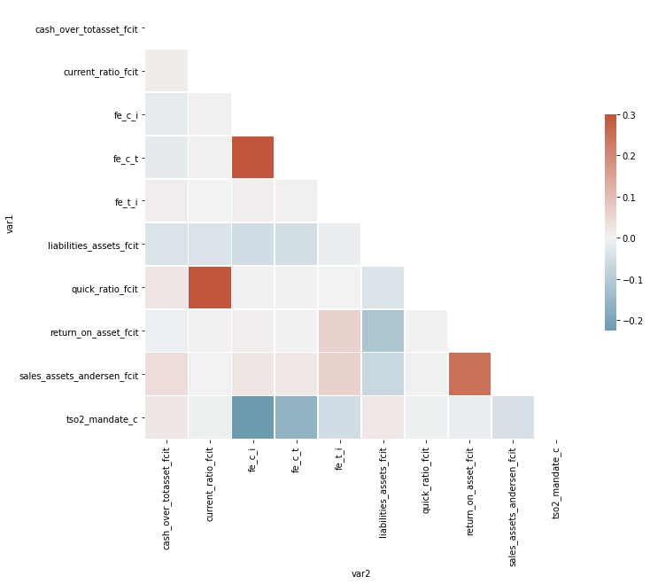

## Scatterplot

From the correlation plot above, pick up a $y$ variables.

We only plot the variables that succeed the Anova test, minus the $y$ var.

Besides, to avoid loading all the table, we have implemented the following rule:

if the size of the table is above >150K rows, then we randomly load 150K rows

First of all, you need to define the Y-axis variables

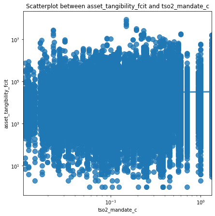

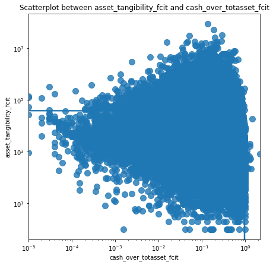

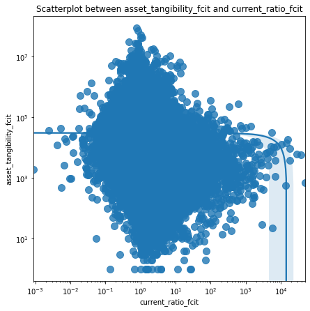

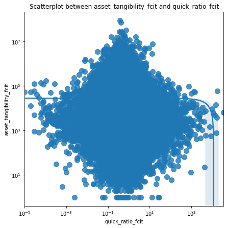

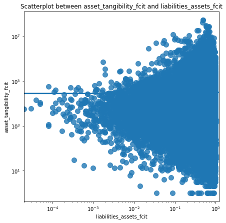

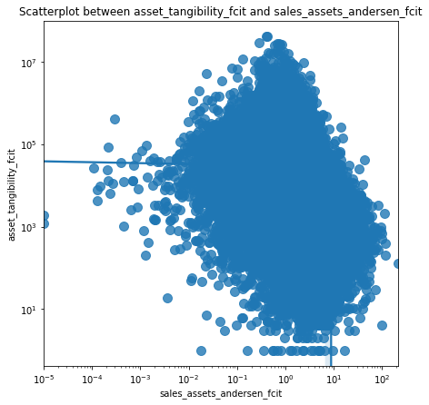

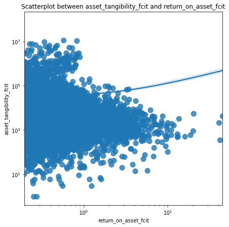

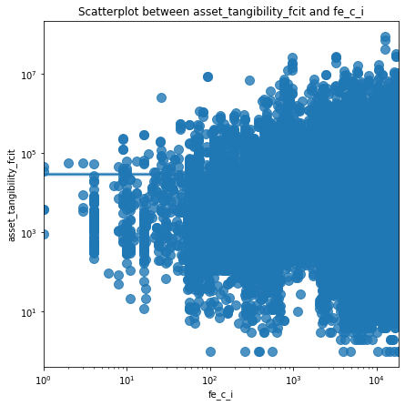

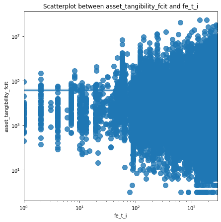

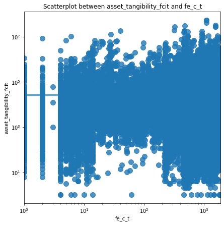

### Diverging bars

The diverging bar plot is plotting for the variables to succeed the Anova test

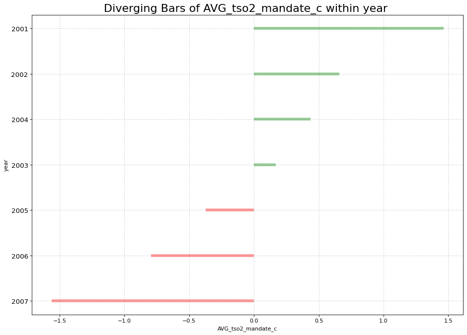

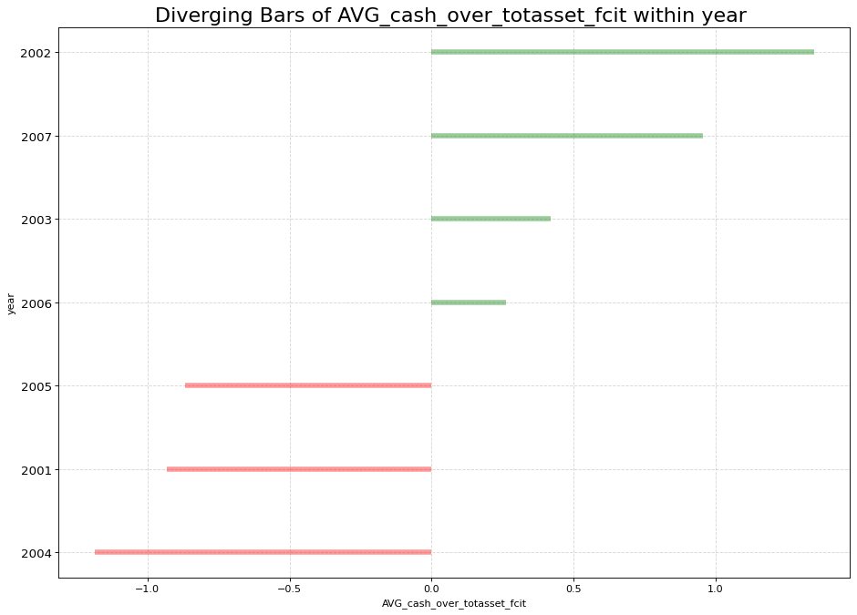

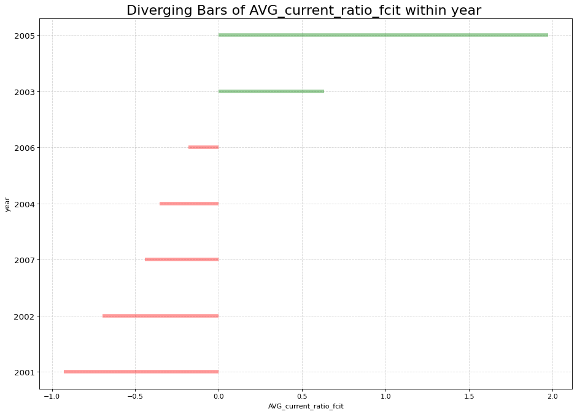

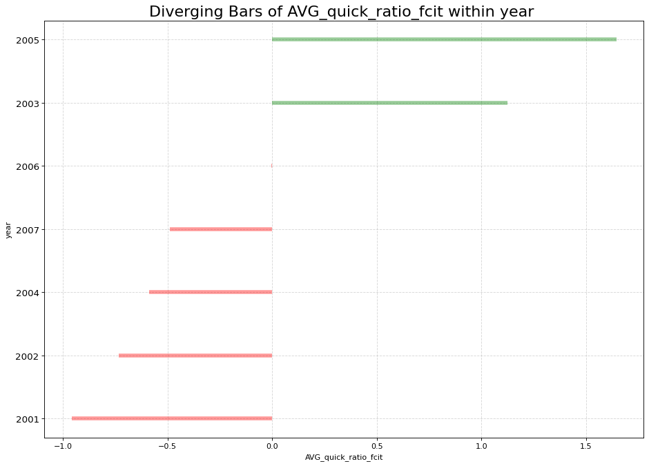

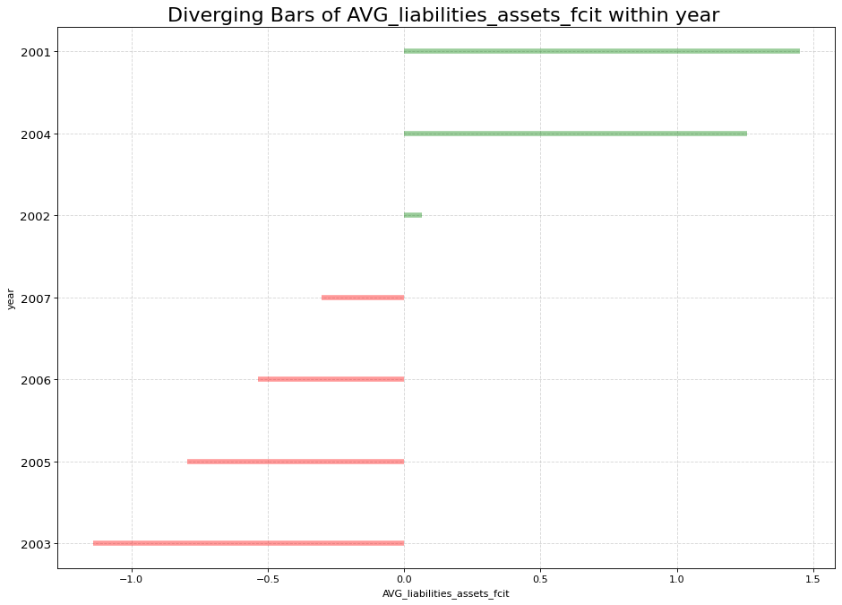

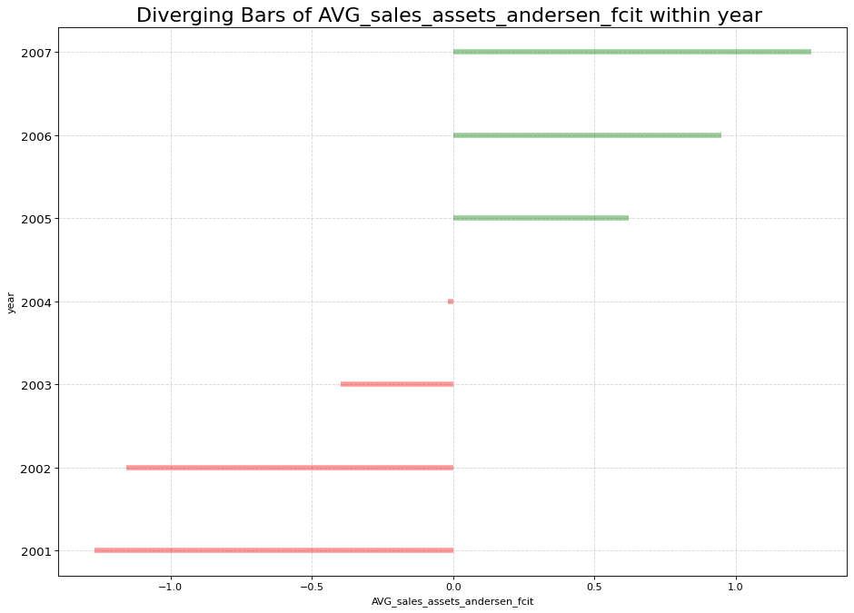

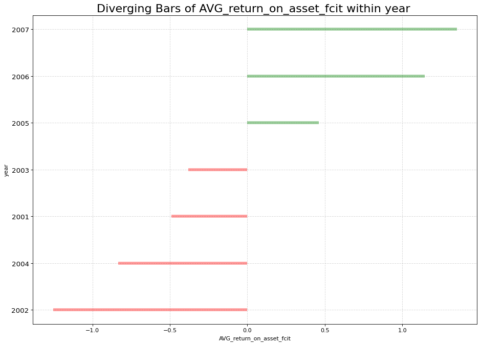

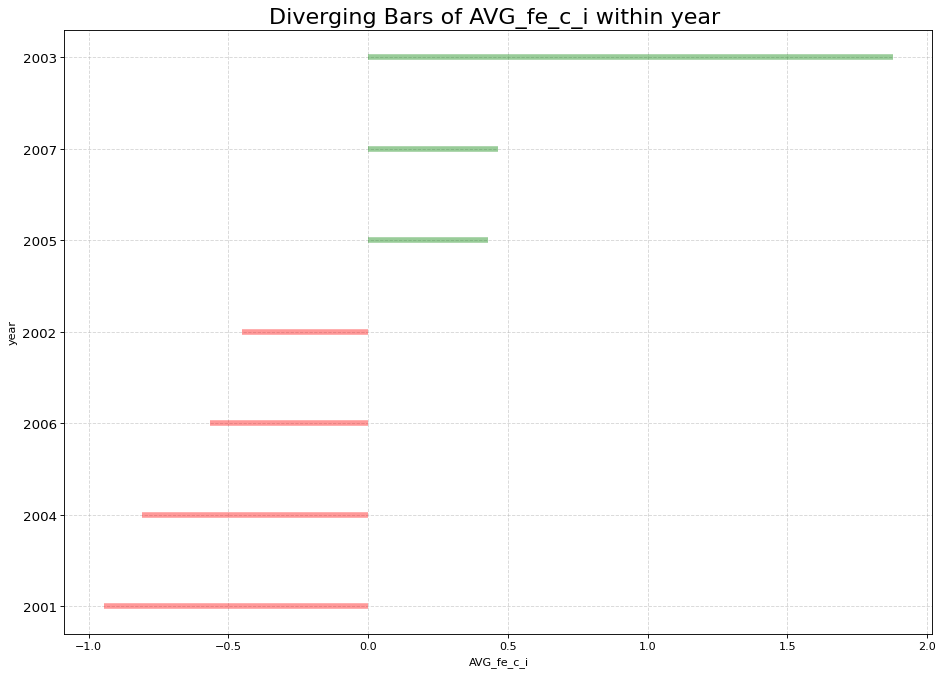

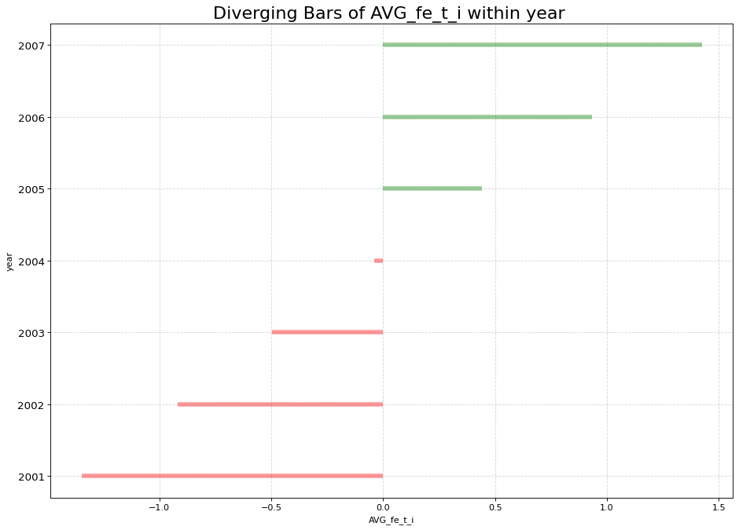

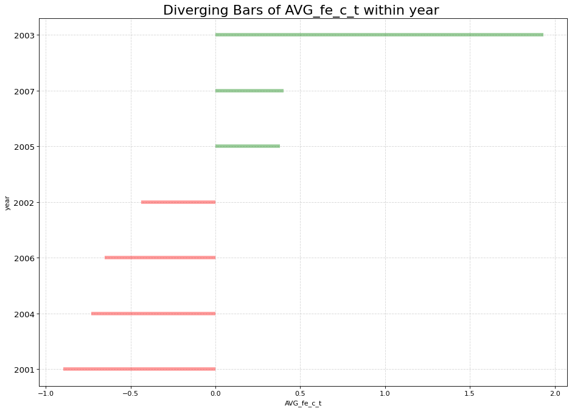